# HW 10 / Exam 2 rough draft

prop_test() and t_test()

Author

SOLUTIONS

This activity continues to introduce you to how to how to conduct hypothesis tests and confidence intervals in R. This is the type of analysis you will be asked to conduct on Exam 2.

## Loading packages

For this analysis, we need the `tidyverse`, `infer`, and `NHANES` packages.

```r
library(tidyverse)
library(infer)
library(NHANES)
```

## A note about typing mathematical symbols in R

Below are some examples for how to type common mathematical symbols we use in this class:

- Greek letter “mu”: $\mu$
- Greek letter “alpha”: $\alpha$
- “X-bar”: $\bar{X}$
- “p-hat”: $\hat{p}$
- Null hypothesis: $H_0$
- Alternative hypothesis: $H_A$
- Not equal to: $\neq$

# Research Question 1: Belief in afterlife

In 2016, one of the questions on the General Social Survey (GSS) was whether or not respondents believed in life after death. Suppose we are interested in investigating the question: do women and men believe in life after death at different rates? The following code loads a random sample of data from the 2016 GSS.

```r
gss2016 <- read_csv("https://docs.google.com/spreadsheets/d/e/2PACX-1vSXStAOCL3Y19OuZAoREVDHKzgiBycVo5h5NRvkU3l4IB81kx-BMU4hurcpWSdfYszJIRQJZ7QblJ8-/pub?output=csv")
```

### Exercise 1

What is the parameter of interest? What notation do we use for it?

> The difference in proportions between women and men who believe in life after death, $p_1 - p_2$

### Exercise 2

State the hypotheses to investigate this question (using symbols):

$$H_0: p_1 - p_2 = 0$$
$$H_A: p_1 - p_2 \neq 0$$

### Exercise 3

The following code gives a glimpse of the data and then creates a stacked bar plot to investigate whether males and females believe in the afterlife at different rates.

```r
glimpse(gss2016)
```

```
Rows: 137
Columns: 14
$ id       <dbl> 2111, 62, 508, 1469, 184, 6, 2063, 2201, 1501, 1139, 2288, 88…
$ year     <dbl> 2016, 2016, 2016, 2016, 2016, 2016, 2016, 2016, 2016, 2016, 2…
$ age      <dbl> 61, 35, 21, 22, 32, 53, 41, 67, 55, 48, 21, 27, 56, 80, 26, 5…
$ class    <chr> "MIDDLE CLASS", "MIDDLE CLASS", "MIDDLE CLASS", "WORKING CLAS…
$ degree   <chr> "HIGH SCHOOL", "HIGH SCHOOL", "HIGH SCHOOL", "HIGH SCHOOL", "…
$ sex      <chr> "FEMALE", "MALE", "FEMALE", "MALE", "MALE", "FEMALE", "FEMALE…
$ marital  <chr> "MARRIED", "WIDOWED", "NEVER MARRIED", "NEVER MARRIED", "NEVE…
$ race     <chr> "WHITE", "BLACK", "WHITE", "WHITE", "BLACK", "WHITE", "WHITE"…
$ region   <chr> "E. NOR. CENTRAL", "MIDDLE ATLANTIC", "NEW ENGLAND", "MOUNTAI…
$ partyid  <chr> "IND,NEAR REP", "INDEPENDENT", "STRONG DEMOCRAT", "IND,NEAR D…
$ postlife <chr> "YES", "YES", "YES", "NO", "NO", "YES", "YES", "YES", "NO", "…
$ happy    <chr> "HAPPY", "UNHAPPY", "UNHAPPY", "HAPPY", "UNHAPPY", "HAPPY", "…
$ relig    <chr> "NONE", "PROTESTANT", "NONE", "NONE", "NONE", "NONE", "CATHOL…
$ cappun   <chr> "FAVOR", "OPPOSE", "OPPOSE", "OPPOSE", "OPPOSE", "OPPOSE", "O…
```

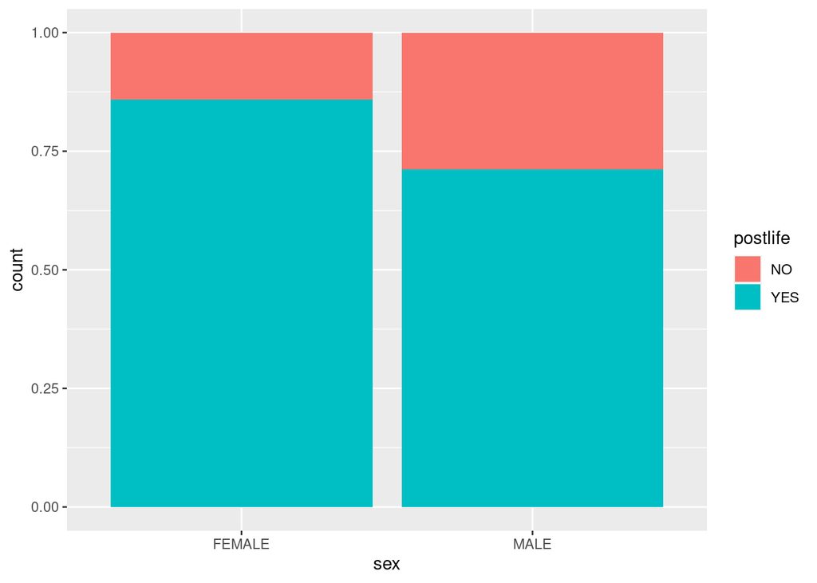

```r
ggplot(data = gss2016, aes(x = sex, fill = postlife)) +
  geom_bar(position = "fill")
```

### Exercise 4

What is the explanatory variable in this case, and which one is the response?

> explanatory = sex, response = postlife

### Exercise 5

If you instead wanted to investigate whether males and females support the death penalty at different rates, what would you change about the code above for the stacked bar plot? Note: the variable `cappun` records respondents’ beliefs on the death penalty (capital punishment).

> set `fill = cappun` instead of `fill = postlife`

## Computing the point estimate

The following code computes proportions of each sex who believe in life after death.

```r
gss2016 %>%
  group_by(sex) %>%
  summarize(count = sum(postlife == "YES"),
            n = n()) %>%
  mutate(p_hat = count/n)
```

```
# A tibble: 2 × 4
  sex    count     n   p_hat
  <chr>  <int> <int>   <dbl>
1 FEMALE    73    85 0.85882
2 MALE      37    52 0.71154
```

### Exercise 6

Recall our research question: *Do the sample data provide strong evidence that males and females believe in the afterlife at different rates?* Based on the above output, what is the relevant point estimate for this research question? What notation do we use for this point estimate?

> 0.85882 - 0.71154 = 0.14728, $\hat{p}_1 - \hat{p}_2$

## Conducting the hypothesis test

Similar to inference for one proportion, `prop_test()` is the function we use to conduct a hypothesis test for a difference in proportions. It returns the appropriate p-value. As a reminder, HW 09 discussed the following inputs to `prop_test()` for a test of one proportion:

- the first input should be the name of the dataset
- `response` = the name of the variable of interest
- `p` = the value specified under the null hypothesis
- `success` = the category corresponding to a “success”. You should put the name of the category in quotations
- `z` = TRUE - this specifies that we want to use the normal distribution and a z-score to conduct the test.
- `conf_level` = a numeric value between 0 and 1 to specify the level of confidence. Default value is 0.95.

The same code applies for a test of two proportions, with two changes:

- remove the `p` argument
- add the argument `explanatory` to specify the name of the explanatory variable (that specifies the two groups)

### Exercise 7

What conditions do we need to check in order to use the normal distribution for this test of a difference in proportions? Are the conditions met in this case?

> Independence - met b/c random sample. Are there at least 10 successes and at least 10 failures in each group (female/male)? Yes; there are 73 and 37 "successes" and 85-73 = 12 and 52 – 37 = 15 "failures" (seen from `count` and `n - count` in the above output.

### Exercise 8

Fill in the appropriate code to conduct the test for the difference in proportions in this context. Once you have the code working, make sure to remove `eval = FALSE` so the output will appear in your html.

```r
prop_test(gss2016, response = postlife, explanatory = sex,
          success = "YES", z = TRUE)
```

[output not shown]

### Exercise 9

Based on the above output, what is the Z-score and the corresponding p-value for this test?

> Z-score = 2.10, p-value = 0.0355

### Exercise 10

Interpret the p-value. Think: “Probability of what, assuming what?”

> The probability of observing a difference in proportions as extreme as 0.147, assuming H0 is true, is 0.035

### Exercise 11

State the conclusion that can be drawn from this study. (use the p-value, state your conclusion in terms of the hypotheses, and assume the researchers used a $\alpha$ threshold of 0.01).

> Because our p-value of 0.035 is greater than 0.01, we fail to reject H0. There is insufficient evidence to claim that women and men believe in the after life at different rates.

Note the `prop_test()` output also gave a confidence interval. However, the default is to use a 95% confidence interval (conf_level = 0.95 by default). Since we used an $\alpha$ threshold of 0.01, we should use a 99% confidence interval instead.

### Exercise 12:

Copy, paste, tweak code from Exercise 8 to construct a 99% confidence interval. *Hint: you can add an argument called `conf_level` to `prop_test()`*

```r
prop_test(gss2016, response = postlife, explanatory = sex,
          success = "YES", z = TRUE, conf_level = 0.99)
```

[output not shown]

### Exercise 13

Interpret the confidence interval in the context of the problem.

### Exercise 14

How could we use the confidence interval to make a decision about the hypothesis test above?

> Because the confidence interval includes 0 (the null value), we fail to reject H0.

# Research Question 2

**Do men or women have a higher BMI on average, or is there no difference?** Use this research question in Exercises 15 - 22.

The code below loads the same data that was used in the HW 09 packet.

```r
NHANES_1112 <- NHANES %>%
  filter(SurveyYr == "2011_12") %>%
  drop_na(Pulse, BMI)
```

Use `NHANES_1112` for all of the analyses below.

### Exercise 15

State the hypotheses to investigate this question (using symbols):

$$H_0: \mu_1 = \mu_2$$
$$H_A: \mu_1 \neq \mu_2$$

### Exercise 16

What is the parameter of interest? What notation do we use for it?

> The parameter of interest is a difference in means, in particular, the difference in average BMI between women and men. We use the notation $\mu_1 - \mu_2$ where $\mu_1$ represents the average BMI for women, and $\mu_2$ represents the average BMI for men.

## Computing the point estimate

The following code computes the average BMI for each group (Gender).

```r
NHANES_1112 %>%
  group_by(Gender) %>%
  summarize(avg_bmi = mean(BMI))
```

```
# A tibble: 2 × 2
  Gender avg_bmi
  <fct>    <dbl>
1 female  27.406
2 male    27.459
```

### Exercise 17

What is the point estimate for this research question? What notation do we use for it?

> 27.406 - 27.459 = -0.053, $\bar{x}_1 - \bar{x}_2$

### Exercise 18

What would you need to change about the code above if you wanted to compute average BMI by Marital Status?

> replace `Gender` with `MaritalStatus`

## Conducting a test for a difference in means using `t_test()`

Let’s conduct a hypothesis test to investigate the question of whether males or females have higher BMI on average, using significance level $\alpha = 0.01$. Similar to inference for one mean, `t_test()` is the function we use to conduct a hypothesis test for a difference in means. It returns the appropriate point estimate and p-value. As a reminder, the input needed for `t_test()` for a test of one mean is:

- the first input should be the name of the dataset
- `response` = the name of the variable of interest
- `mu` = the value specified under the null hypothesis
- `alternative` = “two-sided” by default, can be changed to “greater” or “less” depending on how the alternative hypothesis is specified.
- `conf_level` = a numeric value between 0 and 1 to specify the level of confidence. Default value is 0.95.

The same code applies for a test of two means, with one change:

- add the argument `explanatory` to specify the name of the explanatory variable (that determines the two groups whose means should be compared)

Additionally, note that the null value for a difference in means is often 0, which is the default value of `mu` in `t_test()`, so this argument does not have to be included in this case.

### Exercise 19

Fill in the code to conduct the hypothesis test for the difference in male and female BMI. Use $\alpha = 0.01$. Remove `eval = FALSE` when you have the correct code.

```r
t_test(NHANES_1112, response = BMI, explanatory = Gender,
       conf_level = 0.99)
```

[output not shown]

### Exercise 20

What conclusion would you draw from this hypothesis test? Justify your conclusion using the p-value.

> The p-value for this test is 0.80533, which is greater than $\alpha = 0.01$, so we fail to reject $H_0$. There is insufficient evidence to claim that men and women have different average BMI.

### Exercise 21

Interpret the confidence interval provided by the output above.

> We are 99% confident that the true difference in average BMI between men and women in the US population is between -0.59917 and 0.49456

### Exercise 22

Explain how you could use this confidence interval to make a decision about your hypothesis test.

> Because this confidence interval includes 0 (i.e. the null value, since $H_0: \mu_1 - \mu_2 = 0$), then we fail to reject $H_0$.

# HW 09 Code for Reference

```r
#load child_choice data
child_choice <- read_csv("https://docs.google.com/spreadsheets/d/e/2PACX-1vQpRItBQtDXie32T2QZygOPNBEOui1Gqz6XP-Q-g-zj4tRCkg7W8_-3Y6u8vFK8AoJkH4wHxNLiRLth/pub?gid=0&single=true&output=csv")
#glimpse the dataset to see dimensions, variable names, etc
glimpse(child_choice)
```

```
Rows: 283
Columns: 1
$ choice <chr> "toy", "candy", "candy", "toy", "candy", "candy", "toy", "candy…
```

```r
#computing the sample proportion
child_choice %>%
  summarize(n = n(),
count = sum(choice == "candy")) %>% mutate(p_hat = count/n)
```

```
# A tibble: 1 × 3
      n count   p_hat
  <int> <int>   <dbl>
1   283   148 0.52297
```

```r
#hypothesis test for one proportion
prop_test(child_choice, response = choice, p = 0.5,
          success = "candy", z = TRUE)
```

```
# A tibble: 1 × 3
  statistic p_value alternative
      <dbl>   <dbl> <chr>
1   0.77277 0.43966 two.sided
```

```r
#computing Z score "by hand"
p_hat <- 0.523
p0 <- 0.5
n <- 283
SE <- sqrt(p0*(1-p0)/n)
Z <- (p_hat - p0)/SE
Z
```

```
[1] 0.7738398
```

```r
#computing p-value "by hand"
2*pnorm(Z, lower.tail = FALSE)
```

```
[1] 0.4390255
```

```r
#confidence interval for one proportion
prop_test(child_choice, response = choice,
          success = "candy", z = TRUE)
```

```
No `p` argument was hypothesized, so the test will assume a null hypothesis `p = .5`.
```

[output not shown]

```r
#lower bound of CI "by hand"
p_hat - 1.96*sqrt(p_hat*(1- p_hat)/n)
```

```
[1] 0.4648067
```

```r
#upper bound of CI "by hand"
p_hat + 1.96*sqrt(p_hat*(1- p_hat)/n)
```

```
[1] 0.5811933
```